# Data Wrangling

Rajib Debnath (3856291)

## Required packages

```r
# Loading required required packages

library(readr)
library(Hmisc)
library(tidyr)
library(dplyr)
library(writexl)
library(editrules)
library(outliers)
library(forecast)
```

## Data

A detailed description of datasets considered for data preprocessing, their sources, and variable descriptions are as follows:

#### Dataset Source

I have collected GDP per Capita (dataset 1) and additional country details data (dataset 2) from the following website: https://data.worldbank.org/indicator/NY.GDP.PCAP.CD

I have collected Health spending data of the OECD countries for the period 2000 to 2019 (dataset 3) from the following website: https://data.oecd.org/healthres/health-spending.htm

#### Dataset 1

**GDP per Capita**

While reading the dataset, I had skipped the top four lines as those did not contain any relevant information.

The dataset contained 65 variables and 264 observations. The variables include the following:

- ‘Country Name’: Name of the Country
- ‘Country Code’: Three-letter country codes defined in ISO, a standardized way to represent a country name.
- ‘Indicator Name’: Indicator information - GDP per capita in current USD
- ‘Indicator code’: Code for the Indicator used by the Worldbank database
- 60 columns for GDP data by Years; from year 1960 to 2020
- Last two columns are empty, ‘2020’ and ‘X66’ .

```r
gdp <- read_csv("API_NY.GDP.PCAP.CD_DS2_en_csv_v2_1495171.csv", col_names = TRUE, skip = 4)
head (gdp)
```

| Country Name | Country Code | Indicator Name | Indicator Code | 1960 | 1961 | 1962 | 1963 | 1964 | 1965 | 1966 | 1967 | 1968 | 1969 | 1970 | 1971 | 1972 | 1973 | 1974 | 1975 | 1976 | 1977 | 1978 | 1979 | 1980 | 1981 | 1982 | 1983 | 1984 | 1985 | … |
| --- | --- | --- | --- | --- | --- | --- | --- | --- | --- | --- | --- | --- | --- | --- | --- | --- | --- | --- | --- | --- | --- | --- | --- | --- | --- | --- | --- | --- | --- | --- |
| Aruba | ABW | GDP per capita (current US$) | NY.GDP.PCAP.CD | NA | NA | NA | NA | NA | NA | NA | NA | NA | NA | NA | NA | NA | NA | NA | NA | NA | NA | NA | NA | NA | NA | NA | NA | NA | NA | … |
| Afghanistan | AFG | GDP per capita (current US$) | NY.GDP.PCAP.CD | 59.77319 | 59.86087 | 58.45801 | 78.70639 | 82.09523 | 101.1083 | 137.5944 | 160.8986 | 129.1083 | 129.3297 | 156.5189 | 159.5676 | 135.3173 | 143.1446 | 173.6538 | 186.5109 | 197.4455 | 224.2248 | 247.3541 | 275.7382 | 272.6553 | 264.1113 | NA | NA | NA | NA | … |
| Angola | AGO | GDP per capita (current US$) | NY.GDP.PCAP.CD | NA | NA | NA | NA | NA | NA | NA | NA | NA | NA | NA | NA | NA | NA | NA | NA | NA | NA | NA | NA | 710.9816 | 642.3839 | 619.9614 | 623.4406 | 637.7152 | 758.2376 | … |
| Albania | ALB | GDP per capita (current US$) | NY.GDP.PCAP.CD | NA | NA | NA | NA | NA | NA | NA | NA | NA | NA | NA | NA | NA | NA | NA | NA | NA | NA | NA | NA | NA | NA | NA | NA | 639.4847 | 639.8659 | … |
| Andorra | AND | GDP per capita (current US$) | NY.GDP.PCAP.CD | NA | NA | NA | NA | NA | NA | NA | NA | NA | NA | 3238.5568 | 3498.1737 | 4217.1736 | 5342.1686 | 6319.7390 | 7169.1010 | 7152.3751 | 7751.3702 | 9129.7062 | 11820.8494 | 12377.4116 | 10372.2328 | 9610.2663 | 8022.6548 | 7728.9067 | 7774.3938 | … |
| Arab World | ARB | GDP per capita (current US$) | NY.GDP.PCAP.CD | NA | NA | NA | NA | NA | NA | NA | NA | 224.8787 | 240.0362 | 262.8674 | 295.9717 | 343.5673 | 423.1355 | 777.5626 | 836.2108 | 1007.1433 | 1123.1456 | 1193.7481 | 1563.7073 | 2052.9615 | 2050.7747 | 1864.8757 | 1699.2197 | 1672.2829 | 1606.7598 | … |

- To select only the variables that I would need for my analysis, I considered only ‘Country Name’, ‘Country Code’, and columns from 2000 to 2019 years.
- Renamed ‘Country Code’, and ‘Country Name’.

```r
gdp <- gdp %>%  select('Country Name', 'Country Code', '2000':'2019')
gdp <- gdp %>% rename('country_code' = 'Country Code', 'country_name'='Country Name')

head(gdp)
```

| country_name | country_code | 2000 | 2001 | 2002 | 2003 | 2004 | 2005 | 2006 | 2007 | 2008 | 2009 | 2010 | 2011 | 2012 | 2013 | 2014 | 2015 | 2016 | 2017 | 2018 | 2019 |
| --- | --- | --- | --- | --- | --- | --- | --- | --- | --- | --- | --- | --- | --- | --- | --- | --- | --- | --- | --- | --- | --- |
| Aruba | ABW | 20620.7006 | 20669.0320 | 20436.8871 | 20833.7616 | 22569.9750 | 23300.0396 | 24045.2725 | 25835.1327 | 27084.7037 | 24630.454 | 23512.603 | 24985.9933 | 24713.6980 | 26189.4355 | 26647.9381 | 27980.8807 | 28281.3505 | 29007.693 | NA | NA |
| Afghanistan | AFG | NA | NA | 179.4266 | 190.6838 | 211.3821 | 242.0313 | 263.7337 | 359.6932 | 364.6607 | 438.076 | 543.303 | 591.1628 | 641.8715 | 637.1655 | 613.8567 | 578.4664 | 547.2281 | 556.302 | 524.1629 | 502.1155 |
| Angola | AGO | 556.8363 | 527.3335 | 872.4945 | 982.9609 | 1255.5640 | 1902.4223 | 2599.5665 | 3121.9956 | 4080.9414 | 3122.781 | 3587.884 | 4615.4680 | 5100.0958 | 5254.8823 | 5408.4105 | 4166.9797 | 3506.0729 | 4095.813 | 3289.6467 | 2973.5912 |
| Albania | ALB | 1126.6833 | 1281.6594 | 1425.1248 | 1846.1188 | 2373.5798 | 2673.7873 | 2972.7433 | 3595.0372 | 4370.5401 | 4114.140 | 4094.350 | 4437.1429 | 4247.6300 | 4413.0609 | 4578.6320 | 3952.8012 | 4124.0557 | 4531.021 | 5284.3802 | 5352.8574 |
| Andorra | AND | 21854.2468 | 22971.5355 | 25066.8822 | 32271.9639 | 37969.1750 | 40066.2569 | 42675.8128 | 47803.6936 | 48718.4969 | 43503.186 | 40852.667 | 43335.3289 | 38686.4613 | 39538.7667 | 41303.9294 | 35762.5231 | 37474.6654 | 38962.880 | 41793.0553 | 40886.3912 |
| Arab World | ARB | 2606.0766 | 2510.2619 | 2476.6960 | 2736.4821 | 3134.6735 | 3765.8205 | 4359.8080 | 4963.5415 | 6146.3917 | 5176.528 | 5934.291 | 6867.6920 | 7465.1517 | 7519.8083 | 7457.4611 | 6387.6606 | 6097.2390 | 6102.211 | 6603.3512 | 6580.0563 |

#### Dataset 2

**Country details**

The dataset contained:

- ‘Country Code’: Three-letter country codes defined in ISO, a standardized way to represent a country name.
- ‘Region’: Region of the country ‘IncomeGroup’: Classification of the country based on income as defined by the Worldbank
- ‘SpecialNotes’: Special notes about the country
- ‘TableName’: Contains name of the Country; and
- last column ‘X6’ was empty.

```r
country <- read_csv("Metadata_Country_API_NY.GDP.PCAP.CD_DS2_en_csv_v2_1495171.csv", col_names = TRUE)
head (country)
```

| Country Code | Region | IncomeGroup | SpecialNotes | TableName | X6 |
| --- | --- | --- | --- | --- | --- |
| ABW | Latin America & Caribbean | High income | NA | Aruba | NA |
| AFG | South Asia | Low income | NA | Afghanistan | NA |
| AGO | Sub-Saharan Africa | Lower middle income | NA | Angola | NA |
| ALB | Europe & Central Asia | Upper middle income | NA | Albania | NA |
| AND | Europe & Central Asia | High income | NA | Andorra | NA |
| ARB | NA | NA | Arab World aggregate. Arab World is composed of members of the League of Arab States. | Arab World | NA |

```r
NA
```

To Select only the variable that I would need for my analysis, I had considered only ‘Country Code’, ‘Region’ and ‘IncomeGroup’.

```r
country <- country %>%  select('Country Code', 'Region', 'IncomeGroup')
country <- country %>% rename('country_code' = 'Country Code')
head(country)
```

| country_code | Region | IncomeGroup |
| --- | --- | --- |
| ABW | Latin America & Caribbean | High income |
| AFG | South Asia | Low income |
| AGO | Sub-Saharan Africa | Lower middle income |
| ALB | Europe & Central Asia | Upper middle income |
| AND | Europe & Central Asia | High income |
| ARB | NA | NA |

#### Dataset 3

**Health Spending of OECD Countries**

The dataset contained:

- ‘LOCATION’: Three-letter country codes defined in ISO, a standardized way to represent a country name.
- ‘INDICATOR’: Indicator information i.e. HEALTHEXP- Health spend by a country in a year in USD per capita
- ‘SUBJECT’: Total level
- ‘MEASURE’: USD_CAP i.e. in USD per Capita
- ‘FREQUENCY’: A i.e. Yearly measure
- ‘TIME’: Year of measurement
- ‘Value’: Health spend value in USD
- ‘Flag Codes’: Contains code for each country

```r
health <- read_csv("Health spending OECD.csv", col_names = TRUE)
head (health)
```

| LOCATION | INDICATOR | SUBJECT | MEASURE | FREQUENCY | TIME | Value | Flag Codes |
| --- | --- | --- | --- | --- | --- | --- | --- |
| AUS | HEALTHEXP | TOT | USD_CAP | A | 2000 | 2153.657 | D |
| AUS | HEALTHEXP | TOT | USD_CAP | A | 2001 | 2289.340 | D |
| AUS | HEALTHEXP | TOT | USD_CAP | A | 2002 | 2481.046 | D |
| AUS | HEALTHEXP | TOT | USD_CAP | A | 2003 | 2577.124 | D |
| AUS | HEALTHEXP | TOT | USD_CAP | A | 2004 | 2816.707 | D |
| AUS | HEALTHEXP | TOT | USD_CAP | A | 2005 | 2872.440 | D |

```r
NA
```

- Considering the analysis objective, I considered only ‘LOCATION’, ‘TIME’ and ‘Value’.
- To maintain consistency across datasets and naming simplicity, I renamed ‘LOCATION’=‘country_code’, ‘TIME’=‘Year’ and ‘’Value’=‘health_expense’.

```r
health <- health %>%  select('LOCATION', 'TIME', 'Value')

health <- health %>% rename('country_code' = 'LOCATION', 'Year'='TIME', 'health_expense'='Value')

head(health)
```

| country_code | Year | health_expense |
| --- | --- | --- |
| AUS | 2000 | 2153.657 |
| AUS | 2001 | 2289.340 |
| AUS | 2002 | 2481.046 |
| AUS | 2003 | 2577.124 |
| AUS | 2004 | 2816.707 |
| AUS | 2005 | 2872.440 |

## Understand

#### Dataset 1

**GDP per Capita**

Inspection of dataset 1 structure and attribute revealed that:

- ‘country_name’ and ‘country_code’ were of character class which was suitable. GDP values in each year columns from 2000 to 2019 were in numeric class and this was suitable for the analysis.
- So no data type conversion was required for dataset 1.

```r
str (gdp)
```

```
tibble [264 x 22] (S3: tbl_df/tbl/data.frame)
 $ country_name: chr [1:264] "Aruba" "Afghanistan" "Angola" "Albania" ...
 $ country_code: chr [1:264] "ABW" "AFG" "AGO" "ALB" ...
 $ 2000        : num [1:264] 20621 NA 557 1127 21854 ...
 $ 2001        : num [1:264] 20669 NA 527 1282 22972 ...
 $ 2002        : num [1:264] 20437 179 872 1425 25067 ...
 $ 2003        : num [1:264] 20834 191 983 1846 32272 ...
 $ 2004        : num [1:264] 22570 211 1256 2374 37969 ...
 $ 2005        : num [1:264] 23300 242 1902 2674 40066 ...
 $ 2006        : num [1:264] 24045 264 2600 2973 42676 ...
 $ 2007        : num [1:264] 25835 360 3122 3595 47804 ...
 $ 2008        : num [1:264] 27085 365 4081 4371 48718 ...
 $ 2009        : num [1:264] 24630 438 3123 4114 43503 ...
 $ 2010        : num [1:264] 23513 543 3588 4094 40853 ...
 $ 2011        : num [1:264] 24986 591 4615 4437 43335 ...
 $ 2012        : num [1:264] 24714 642 5100 4248 38686 ...
 $ 2013        : num [1:264] 26189 637 5255 4413 39539 ...
 $ 2014        : num [1:264] 26648 614 5408 4579 41304 ...
 $ 2015        : num [1:264] 27981 578 4167 3953 35763 ...
 $ 2016        : num [1:264] 28281 547 3506 4124 37475 ...
 $ 2017        : num [1:264] 29008 556 4096 4531 38963 ...
 $ 2018        : num [1:264] NA 524 3290 5284 41793 ...
 $ 2019        : num [1:264] NA 502 2974 5353 40886 ...
```

```r
attributes(gdp)
```

```
$names
 [1] "country_name" "country_code" "2000"         "2001"         "2002"         "2003"         "2004"         "2005"         "2006"         "2007"
[11] "2008"         "2009"         "2010"         "2011"         "2012"         "2013"         "2014"         "2015"         "2016"         "2017"
[21] "2018"         "2019"

$row.names
  [1]   1   2   3   4   5   6   7   8   9  10  11  12  13  14  15  16  17  18  19  20  21  22  23  24  25  26  27  28  29  30  31  32  33  34  35  36  37  38
 [39]  39  40  41  42  43  44  45  46  47  48  49  50  51  52  53  54  55  56  57  58  59  60  61  62  63  64  65  66  67  68  69  70  71  72  73  74  75  76
 [77]  77  78  79  80  81  82  83  84  85  86  87  88  89  90  91  92  93  94  95  96  97  98  99 100 101 102 103 104 105 106 107 108 109 110 111 112 113 114
[115] 115 116 117 118 119 120 121 122 123 124 125 126 127 128 129 130 131 132 133 134 135 136 137 138 139 140 141 142 143 144 145 146 147 148 149 150 151 152
[153] 153 154 155 156 157 158 159 160 161 162 163 164 165 166 167 168 169 170 171 172 173 174 175 176 177 178 179 180 181 182 183 184 185 186 187 188 189 190
[191] 191 192 193 194 195 196 197 198 199 200 201 202 203 204 205 206 207 208 209 210 211 212 213 214 215 216 217 218 219 220 221 222 223 224 225 226 227 228
[229] 229 230 231 232 233 234 235 236 237 238 239 240 241 242 243 244 245 246 247 248 249 250 251 252 253 254 255 256 257 258 259 260 261 262 263 264

$class
[1] "tbl_df"     "tbl"        "data.frame"
```

#### Dataset 2

**Country details**

Inspected dataset 2 structure and attribute.

```r
str (country)
```

```
tibble [263 x 3] (S3: tbl_df/tbl/data.frame)
 $ country_code: chr [1:263] "ABW" "AFG" "AGO" "ALB" ...
 $ Region      : chr [1:263] "Latin America & Caribbean" "South Asia" "Sub-Saharan Africa" "Europe & Central Asia" ...
 $ IncomeGroup : chr [1:263] "High income" "Low income" "Lower middle income" "Upper middle income" ...
```

```r
attributes(country)
```

```
$names
[1] "country_code" "Region"       "IncomeGroup"

$row.names
  [1]   1   2   3   4   5   6   7   8   9  10  11  12  13  14  15  16  17  18  19  20  21  22  23  24  25  26  27  28  29  30  31  32  33  34  35  36  37  38
 [39]  39  40  41  42  43  44  45  46  47  48  49  50  51  52  53  54  55  56  57  58  59  60  61  62  63  64  65  66  67  68  69  70  71  72  73  74  75  76
 [77]  77  78  79  80  81  82  83  84  85  86  87  88  89  90  91  92  93  94  95  96  97  98  99 100 101 102 103 104 105 106 107 108 109 110 111 112 113 114
[115] 115 116 117 118 119 120 121 122 123 124 125 126 127 128 129 130 131 132 133 134 135 136 137 138 139 140 141 142 143 144 145 146 147 148 149 150 151 152
[153] 153 154 155 156 157 158 159 160 161 162 163 164 165 166 167 168 169 170 171 172 173 174 175 176 177 178 179 180 181 182 183 184 185 186 187 188 189 190
[191] 191 192 193 194 195 196 197 198 199 200 201 202 203 204 205 206 207 208 209 210 211 212 213 214 215 216 217 218 219 220 221 222 223 224 225 226 227 228
[229] 229 230 231 232 233 234 235 236 237 238 239 240 241 242 243 244 245 246 247 248 249 250 251 252 253 254 255 256 257 258 259 260 261 262 263

$class
[1] "tbl_df"     "tbl"        "data.frame"
```

Data inspection revealed that ‘country_code’ was of character class which was suitable. However, ‘Region’ should be in qualitative data and as I would need it to be ordered just alphabetically without any priority, so I had converted it to an unordered factor.

```r
country$Region <- country$Region %>% as.factor()
class(country$Region)
```

```
[1] "factor"
```

```r
levels(country$Region)
```

```
[1] "East Asia & Pacific"        "Europe & Central Asia"      "Latin America & Caribbean"  "Middle East & North Africa" "North America"
[6] "South Asia"                 "Sub-Saharan Africa"
```

‘IncomeGroup’ should be in qualitative data and with a meaningful order. So, I had converted it to an ordered factored (from low to high income).

```r
country$IncomeGroup <- factor(country$IncomeGroup, levels=c("Low income", "Lower middle income",
                    "Upper middle income", "High income"), ordered=TRUE)
class(country$IncomeGroup)
```

```
[1] "ordered" "factor"
```

```r
levels(country$IncomeGroup)
```

```
[1] "Low income"          "Lower middle income" "Upper middle income" "High income"
```

#### Dataset 3

**Health Spending of OECD Countries**

- Inspected dataset 3 structure and attribute (*due to page constraint, not showed dataset attribute*).
- ‘health_expense’ was in numeric class and this was suitable for the analysis.

```r
str (health)
```

```
tibble [729 x 3] (S3: tbl_df/tbl/data.frame)
 $ country_code  : chr [1:729] "AUS" "AUS" "AUS" "AUS" ...
 $ Year          : num [1:729] 2000 2001 2002 2003 2004 ...
 $ health_expense: num [1:729] 2154 2289 2481 2577 2817 ...
```

```r
#attributes(health) - Due to page constraint, not showed dataset attribute.
```

```r
health$country_code <- health$country_code %>% as.factor()
health$Year <- health$Year %>% factor(levels = c('2000','2001','2002','2003','2004','2005','2006','2007','2008','2009','2010','2011','2012','2013','2014','2015','2016','2017','2018','2019'),ordered = TRUE)
class(health$country_code)
```

```
[1] "factor"
```

```r
class(health$Year)
```

```
[1] "ordered" "factor"
```

```r
levels(health$Year)
```

```
 [1] "2000" "2001" "2002" "2003" "2004" "2005" "2006" "2007" "2008" "2009" "2010" "2011" "2012" "2013" "2014" "2015" "2016" "2017" "2018" "2019"
```

## Tidy & Manipulate Data I

There are three interrelated rules which make a dataset tidy (Wickham and Grolemund (2016)). In tidy data:

- Each variable must have its own column.
- Each observation must have its own row.
- Each value must have its own cell.

Data Inspection revealed that GDP dataset was untidy because GDP values’ column headers were actually year values, not variable names. Therefore, the ‘Year’ variable did not had its own column. So each row represented twenty observations, not one. So I have transformed the data from wide to long format using the gather() function.

```r
gdp <- gdp %>% gather(`2000`:`2019`, key = "Year",value = GDP)
head(gdp)
```

| country_name | country_code | Year | GDP |
| --- | --- | --- | --- |
| Aruba | ABW | 2000 | 20620.7006 |
| Afghanistan | AFG | 2000 | NA |
| Angola | AGO | 2000 | 556.8363 |
| Albania | ALB | 2000 | 1126.6833 |
| Andorra | AND | 2000 | 21854.2468 |
| Arab World | ARB | 2000 | 2606.0766 |

```r
NA
```

Dataset 2 (‘country’ - Country details) and Dataset 3 (‘health’ - Health Spending of OECD Countries) were fulfilling the Tidy data rules (Wickham and Grolemund (2016)). Hence, no further action needed to reshape these two datasets into a tidy format.

#### Merge Data

All three datasets were in the tidy format then and contained only the required variable in each dataset for the mentioned data analysis objective. After that I have merged three datasets :

- At first I merged Dataset 2 (‘country’ - Country details) to Dataset 1 (‘gdp’- GDP per Capita) using left_join function.
- I have converted the ‘country_code’. ‘country_name’ and ‘Year’ to factor to keep these variable data types class compatible across datasets.

```r
gdp_country <- left_join(gdp, country, by = 'country_code')

gdp_country$country_code <- gdp_country$country_code %>% as.factor()
gdp_country$country_name <- gdp_country$country_name %>% as.factor()
gdp_country$Year <- gdp_country$Year %>% factor(levels = c('2000','2001','2002','2003','2004','2005','2006','2007','2008','2009','2010','2011','2012','2013','2014','2015','2016','2017','2018','2019'),ordered = TRUE)

head(gdp_country)
```

| country_name | country_code | Year | GDP | Region | IncomeGroup |
| --- | --- | --- | --- | --- | --- |
| Aruba | ABW | 2000 | 20620.7006 | Latin America & Caribbean | High income |
| Afghanistan | AFG | 2000 | NA | South Asia | Low income |
| Angola | AGO | 2000 | 556.8363 | Sub-Saharan Africa | Lower middle income |
| Albania | ALB | 2000 | 1126.6833 | Europe & Central Asia | Upper middle income |
| Andorra | AND | 2000 | 21854.2468 | Europe & Central Asia | High income |
| Arab World | ARB | 2000 | 2606.0766 | NA | NA |

```r
NA
```

After that, I wanted to keep only the observations related to the OECD countries. To achieve that, I had filtered rows of the ‘country_code’ column of the gdp_country dataset based on the values of the ‘country_code’ column of the health dataset (which contained only the county codes of OECD countries).

```r
gdp_country <- gdp_country %>% filter(country_code %in% health$country_code)

head(gdp_country)
```

| country_name | country_code | Year | GDP | Region | IncomeGroup |
| --- | --- | --- | --- | --- | --- |
| Australia | AUS | 2000 | 21679.248 | East Asia & Pacific | High income |
| Austria | AUT | 2000 | 24564.458 | Europe & Central Asia | High income |
| Belgium | BEL | 2000 | 23041.535 | Europe & Central Asia | High income |
| Canada | CAN | 2000 | 24190.250 | North America | High income |
| Switzerland | CHE | 2000 | 37868.323 | Europe & Central Asia | High income |
| Chile | CHL | 2000 | 5074.902 | Latin America & Caribbean | High income |

```r
NA
```

- Next step, I merged Dataset 3 (‘health’ - Health Spending of OECD Countries) to gdp_country (merged data for Dataset 1 and 2) using left_join function using both ‘country_code’ and ‘Year’ as the key.
- Further, rounded off GDP and health_expense values to reduce clutter.

```r
gdp_country_health <- left_join(gdp_country, health, by = c("country_code", "Year"))

gdp_country_health$GDP <- gdp_country_health$GDP %>% round()
gdp_country_health$health_expense <- gdp_country_health$health_expense %>% round()

head(gdp_country_health)
```

| country_name | country_code | Year | GDP | Region | IncomeGroup | health_expense |
| --- | --- | --- | --- | --- | --- | --- |
| Australia | AUS | 2000 | 21679 | East Asia & Pacific | High income | 2154 |
| Austria | AUT | 2000 | 24564 | Europe & Central Asia | High income | 2803 |
| Belgium | BEL | 2000 | 23042 | Europe & Central Asia | High income | 2297 |
| Canada | CAN | 2000 | 24190 | North America | High income | 2451 |
| Switzerland | CHE | 2000 | 37868 | Europe & Central Asia | High income | 3325 |
| Chile | CHL | 2000 | 5075 | Latin America & Caribbean | High income | 591 |

```r
NA
```

## Tidy & Manipulate Data II

```r
gdp_country_health<-gdp_country_health %>% mutate("Health_spending_GDP_share"= (health_expense/GDP))

gdp_country_health$Health_spending_GDP_share <- gdp_country_health$Health_spending_GDP_share*100

gdp_country_health$Health_spending_GDP_share <- gdp_country_health$Health_spending_GDP_share %>% round(2)
head(gdp_country_health)
```

| country_name | country_code | Year | GDP | Region | IncomeGroup | health_expense | Health_spending_GDP_share |
| --- | --- | --- | --- | --- | --- | --- | --- |
| Australia | AUS | 2000 | 21679 | East Asia & Pacific | High income | 2154 | 9.94 |
| Austria | AUT | 2000 | 24564 | Europe & Central Asia | High income | 2803 | 11.41 |
| Belgium | BEL | 2000 | 23042 | Europe & Central Asia | High income | 2297 | 9.97 |
| Canada | CAN | 2000 | 24190 | North America | High income | 2451 | 10.13 |
| Switzerland | CHE | 2000 | 37868 | Europe & Central Asia | High income | 3325 | 8.78 |
| Chile | CHL | 2000 | 5075 | Latin America & Caribbean | High income | 591 | 11.65 |

## Scan I

#### Checking for Missing values

Checked data for missing values in each column using colSums() function.

```r
colSums(is.na(gdp_country_health))
```

```
             country_name              country_code                      Year                       GDP                    Region               IncomeGroup
                        0                         0                         0                         0                         0                         0
           health_expense Health_spending_GDP_share
                       11                        11
```

```r
data_missingvalues <- gdp_country_health[rowSums(is.na(gdp_country_health)) > 0,]
data_missingvalues
```

| country_name | country_code | Year | GDP | Region | IncomeGroup | health_expense | Health_spending_GDP_share |
| --- | --- | --- | --- | --- | --- | --- | --- |
| Colombia | COL | 2000 | 2520 | Latin America & Caribbean | Upper middle income | NA | NA |
| Colombia | COL | 2001 | 2440 | Latin America & Caribbean | Upper middle income | NA | NA |
| Colombia | COL | 2002 | 2397 | Latin America & Caribbean | Upper middle income | NA | NA |
| Colombia | COL | 2003 | 2281 | Latin America & Caribbean | Upper middle income | NA | NA |
| Colombia | COL | 2004 | 2783 | Latin America & Caribbean | Upper middle income | NA | NA |
| Colombia | COL | 2005 | 3414 | Latin America & Caribbean | Upper middle income | NA | NA |
| Colombia | COL | 2006 | 3741 | Latin America & Caribbean | Upper middle income | NA | NA |
| Colombia | COL | 2007 | 4714 | Latin America & Caribbean | Upper middle income | NA | NA |
| Colombia | COL | 2008 | 5473 | Latin America & Caribbean | Upper middle income | NA | NA |
| Colombia | COL | 2009 | 5193 | Latin America & Caribbean | Upper middle income | NA | NA |

[output cut: 1 more lines]

```r
NA
```

- So, the dataset did not contain values in ‘health expense’ and corresponding ‘Health_spending_GDP_share’ columns for Colombia from the period 2000 to 2010.
- One way to deal with these missing values would be to recode these missing values with the mean values of Colombia country with the available data; i.e. 2011 to 2020. I tried to investigate if that would be an appropriate thing to do.
- So, calculated mean health expense for the period 2000 to 2010 and 2011 to 2020 for each country.

```r
#mean expense for the period 2000 to 2010
summary1 <- gdp_country_health %>% filter( Year < 2011) %>% group_by(country_name) %>% summarise(
                                          Mean = mean(health_expense, na.rm = TRUE))
summary1
```

| country_name | Mean |
| --- | --- |
| Australia | 2886.3636 |
| Austria | 3512.6364 |
| Belgium | 3109.8182 |
| Canada | 3294.8182 |
| Chile | 896.7273 |
| Colombia | NaN |
| Czech Republic | 1539.2727 |
| Denmark | 3181.8182 |
| Estonia | 924.0909 |
| Finland | 2640.7273 |

[output cut: 27 more lines]

```r
#mean expense for the period 2011 to 2020
summary2 <- gdp_country_health %>% filter( Year > 2010) %>% group_by(country_name) %>% summarise(
                                          Mean = mean(health_expense, na.rm = TRUE))
summary2
```

| country_name | Mean |
| --- | --- |
| Australia | 4421.778 |
| Austria | 5049.667 |
| Belgium | 4693.667 |
| Canada | 4768.111 |
| Chile | 1807.444 |
| Colombia | 1024.000 |
| Czech Republic | 2650.111 |
| Denmark | 4774.556 |
| Estonia | 1929.667 |
| Finland | 4051.333 |

[output cut: 27 more lines]

```r
NA
```

- Comparing the mean values of each country for the above mentioned two periods, it is clear that it had changed drastically over the years. Hence I should not recode the missing values with the mean values of available data for Colombia. Therefore, I had decided to omit the records with missing values from the analysis.
- Further, as it would impact only 11 observations out of 740 observations, the loss of data would not be significant and would not result in a biased subset of the data.
- So, all the missing values had been dealt with.

```r
gdp_country_health <-na.omit(gdp_country_health)
colSums(is.na(gdp_country_health))
```

```
             country_name              country_code                      Year                       GDP                    Region               IncomeGroup
                        0                         0                         0                         0                         0                         0
           health_expense Health_spending_GDP_share
                        0                         0
```

#### Checking for Special values

After that, I had checked each numerical column for any special values like inf, NaN using a function called is.special.

```r
is.special <- function(x){
if (is.numeric(x)) (is.infinite(x) | is.nan(x))
}

# apply this function to the dataset and calculate the total missing values for each column
sapply(df, is.special)
```

```r
gdp_country_health %>% sapply(function(x) sum(is.special(x)))
```

```
             country_name              country_code                      Year                       GDP                    Region               IncomeGroup
                        0                         0                         0                         0                         0                         0
           health_expense Health_spending_GDP_share
                        0                         0
```

So there are no special values in the dataset.

#### Checking for obvious Inconsistencies or Errors

An obvious inconsistency occurs when a data record contains a value that cannot correspond to a real-world situation. I had defined rules to identify obvious inconsistencies or errors on the variables using editset functions and after that checked the datasets against these rules using the violatedEdits function.

In this case, GDP and Health Expense could not be negative.

```r
rule1 <- editset(c("GDP >= 0", "health_expense >= 0"))

sum(violatedEdits(rule1, gdp_country_health))
```

```
[1] 0
```

```r
rule2 <- editset(c("health_expense<GDP","Health_spending_GDP_share < 100"))
sum(violatedEdits(rule2, gdp_country_health))
```

```
[1] 0
```

I had written rules in a text file to ensure ‘IncomeGroup’, ‘Region’ and ‘Year’ variable contain only expected values and used editfile function to read rules directly from the text file.

```r
Rules <- editfile("editrules.txt", type = "all")
Rules
```

```
Data model:
dat1 : IncomeGroup %in% c('High income', 'Low income', 'Lower middle income', 'Upper middle income')
dat2 : Region %in% c('East Asia & Pacific', 'Europe & Central Asia', 'Latin America & Caribbean', 'Middle East & North Africa', 'North America', 'South Asia', 'Sub-Saharan Africa')
dat3 : Year %in% c('2000', '2001', '2002', '2003', '2004', '2005', '2006', '2007', '2008', '2009', '2010', '2011', '2012', '2013', '2014', '2015', '2016', '2017', '2018', '2019')

Edit set:
NULL :
```

and, checked summary of violated rules. So no errors detected.

```r
Violated <- violatedEdits(Rules, gdp_country_health)
summary(Violated)
```

```
No violations detected, 0 checks evaluated to NA
```

- The OECD is an economic organisation with 37 member countries, so checked if I had exactly the same numbers of countries and corresponding country codes in the dataset.
- I had considered 20 years (2000 to 2019) of data, so checked if I had exactly 20 unique values in the ‘Year’ column.
- No errors detected.

```r
length(unique(gdp_country_health[["country_name"]])) == 37
```

```
[1] TRUE
```

```r
length(unique(gdp_country_health[["country_code"]])) == 37
```

```
[1] TRUE
```

```r
length(unique(gdp_country_health[["Year"]])) == 20
```

```
[1] TRUE
```

## Scan II

Next, I scanned numeric data ‘health_expense’ and ‘GDP’ for any potential outlier. I did not need to scan ‘Health_spending_GDP_share’ variable as it was a derived ratio and would have acceptable values as long as underlying ‘health_expense’ and ‘GDP’ data were issue-free.

To understand the presence of univariate outliers (assuming the population distribution of the underlying data is unknown):

- Plotted Boxplot to understand the data and identify potential outliers with −1.5×IQR and 1.5×IQR outlier fences. In that, any value lying outside the fences were depicted as an outlier.
- Identified the values of the potential outliers using the boxplot.stats()$out function

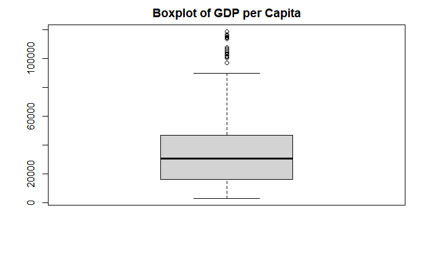

```r
boxplot(gdp_country_health$GDP, main="Boxplot of GDP per Capita")
```

```r
#Inspecting outliers in the GDP data
potential_GDP_outliers <- boxplot.stats(gdp_country_health$GDP)$out %>% round ()
potential_GDP_outliers
```

```
 [1] 106018 114294  96944 103199 104965 115762 100601 106749 101524 113625 102913 118824  97019 101376 104278 107627 116654 114705
```

Plotted boxplot for potential Health Expense per Capita outliers.

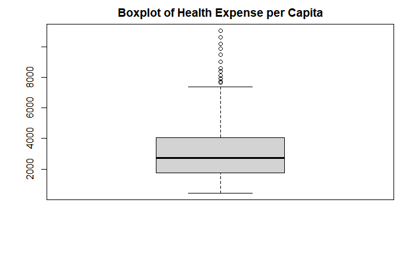

```r
boxplot(gdp_country_health$health_expense, main="Boxplot of Health Expense per Capita")
```

```r
##Inspecting outliers in GDP per Capita
potential_health_outliers <- boxplot.stats(gdp_country_health$health_expense)$out %>% round ()
potential_health_outliers
```

```
 [1]  7670  7922  8131  8405  8611  9034  9498  9880 10213 10637  7732 11072
```

- So there could be some potential abnormal cases.
- I had used which() function to extract the row number corresponding to these potential GDP outliers and inspected the specific rows in the dataset to verify them.
- It was interesting as we know Luxembourg and Norway both are energy exporters, regional financial centers, and export business powerhouses with relatively small populations, might resulted in high GDP per Capita.

```r
GDP_out <- which(gdp_country_health$GDP %in% c(potential_GDP_outliers))
GDP_out_dataset <- gdp_country_health[GDP_out, ]
GDP_out_dataset
```

| country_name | country_code | Year | GDP | Region | IncomeGroup | health_expense | Health_spending_GDP_share |
| --- | --- | --- | --- | --- | --- | --- | --- |
| Luxembourg | LUX | 2007 | 106018 | Europe & Central Asia | High income | 5085 | 4.80 |
| Luxembourg | LUX | 2008 | 114294 | Europe & Central Asia | High income | 5431 | 4.75 |
| Norway | NOR | 2008 | 96944 | Europe & Central Asia | High income | 4605 | 4.75 |
| Luxembourg | LUX | 2009 | 103199 | Europe & Central Asia | High income | 5724 | 5.55 |
| Luxembourg | LUX | 2010 | 104965 | Europe & Central Asia | High income | 5623 | 5.36 |
| Luxembourg | LUX | 2011 | 115762 | Europe & Central Asia | High income | 4831 | 4.17 |
| Norway | NOR | 2011 | 100601 | Europe & Central Asia | High income | 4965 | 4.94 |
| Luxembourg | LUX | 2012 | 106749 | Europe & Central Asia | High income | 4425 | 4.15 |
| Norway | NOR | 2012 | 101524 | Europe & Central Asia | High income | 5210 | 5.13 |
| Luxembourg | LUX | 2013 | 113625 | Europe & Central Asia | High income | 4637 | 4.08 |

[output cut: 8 more lines]

```r
NA
```

- Conducted the same investigation for potential health expense outliers and inspected the specific rows in the dataset to verify them.
- It revealed that potential Health Expense per Capita outliers were present only in data points associated with the United States and Switzerland. It is common knowledge that both the mentioned countries spend huge amount in the health sector.

```r
health_out <- which(gdp_country_health$health_expense %in% c(potential_health_outliers))
gdp_country_health[health_out, ]
```

| country_name | country_code | Year | GDP | Region | IncomeGroup | health_expense | Health_spending_GDP_share |
| --- | --- | --- | --- | --- | --- | --- | --- |
| United States | USA | 2009 | 47100 | North America | High income | 7670 | 16.28 |
| United States | USA | 2010 | 48468 | North America | High income | 7922 | 16.34 |
| United States | USA | 2011 | 49887 | North America | High income | 8131 | 16.30 |
| United States | USA | 2012 | 51611 | North America | High income | 8405 | 16.29 |
| United States | USA | 2013 | 53118 | North America | High income | 8611 | 16.21 |
| United States | USA | 2014 | 55048 | North America | High income | 9034 | 16.41 |
| United States | USA | 2015 | 56823 | North America | High income | 9498 | 16.72 |
| United States | USA | 2016 | 57928 | North America | High income | 9880 | 17.06 |
| United States | USA | 2017 | 59958 | North America | High income | 10213 | 17.03 |
| United States | USA | 2018 | 62840 | North America | High income | 10637 | 16.93 |

[output cut: 2 more lines]

```r
NA
```

- This called for further investigation using a bivariate box plot.
- It revealed that there were no obvious outliers or abnormal observations when we included the respective country into consideration.

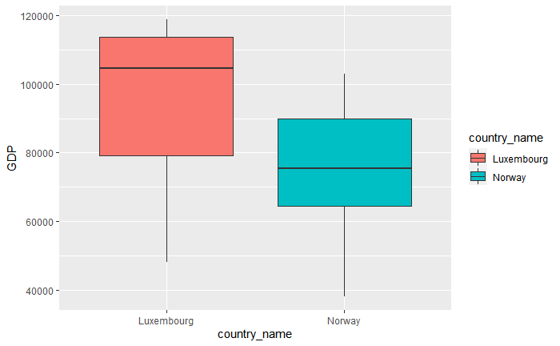

```r
GDP_out <- gdp_country_health %>%  filter( country_name %in% c('Luxembourg', 'Norway'))
health_out <- gdp_country_health %>%  filter( country_name %in% c('United States', 'Switzerland'))

library(ggplot2)
ggplot(GDP_out, aes(country_name, GDP, fill=country_name)) +
  geom_boxplot()
```

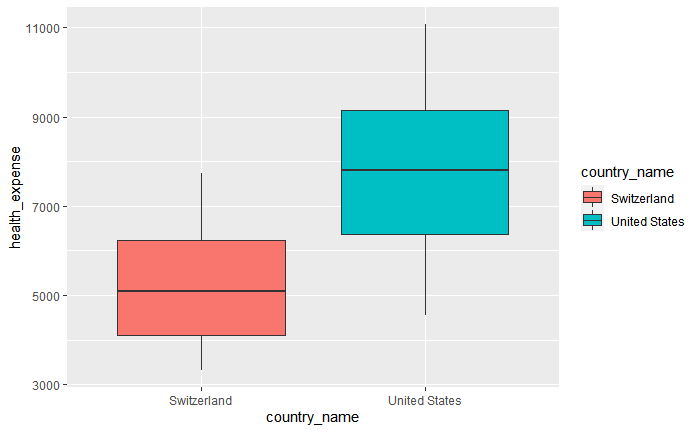

```r
ggplot(health_out, aes(country_name, health_expense, fill=country_name)) +
  geom_boxplot()
```

```r
z_score_GDP <- gdp_country_health$GDP %>%  scores(type = "z")
z_score_GDP %>% summary()
```

```
   Min. 1st Qu.  Median    Mean 3rd Qu.    Max.
-1.3974 -0.8089 -0.1436  0.0000  0.5827  3.8544
```

```r
which( abs(z_score_GDP) >3 )
```

```
 [1] 276 312 348 384 421 425 458 462 495 499 532 569 606 643 680 717
```

```r
z_score_health <- gdp_country_health$health_expense %>%  scores(type = "z")
z_score_health %>% summary()
```

```
   Min. 1st Qu.  Median    Mean 3rd Qu.    Max.
-1.5295 -0.7301 -0.1463  0.0000  0.6459  4.8416
```

```r
which( abs(z_score_health) >3 )
```

```
[1] 433 470 507 544 581 618 655 692 729
```

From the summary() output Max. values, I could see the presence of outliers. Further, which() function showed the locations of the z-scores whose absolute value is greater than 3.

However, in this case, as well, using the above mentioned rationale and analysis, I could conclude that there was no justifiable reason to remove or replace those outliers. So I had kept the outliers unchanged.

## Transform

As one of the key objectives of my data analysis was to understand the relationship between GDP and Health Spend, I would prefer the distribution of those variables to be normal. So I checked the type of skewness in the data before using any transformation to reduce the skewness.

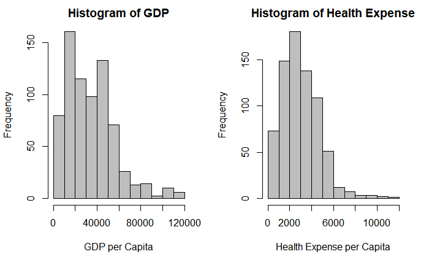

```r
par(mfrow=c(1,2))
gdp_country_health$GDP %>%  hist(col="grey", xlab="GDP per Capita", main="Histogram of GDP")
gdp_country_health$health_expense %>%  hist(col="grey", xlab="Health Expense per Capita", main="Histogram of Health Expense")
```

- I observed that both GDP and Health expense had a right-skewed distribution.
- So, I had applied different data transformation methods and showed below the top three outcomes (i.e. Log transformation, Square root transformation, and Box-Cox Transformation).

```r
par(mfrow=c(1,3))

log_GDP <- log10(gdp_country_health$GDP)
hist(log_GDP, main="Log transformed")

sqrt_GDP <- sqrt(gdp_country_health$GDP)
hist(sqrt_GDP, main="Square root transformed")
```

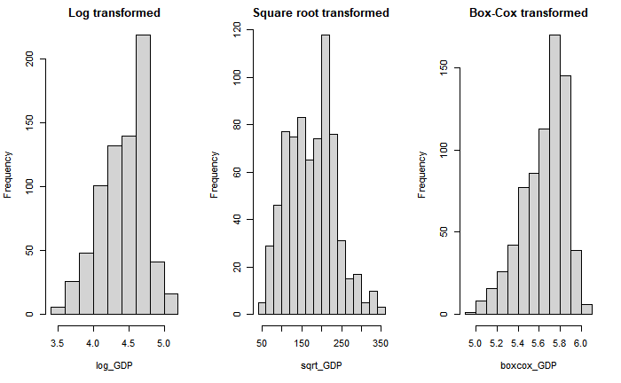

```r
boxcox_GDP<- BoxCox(gdp_country_health$GDP,lambda = "auto")
hist(boxcox_GDP, main="Box-Cox transformed")
```

```r
par(mfrow=c(1,3))

log_health <- log10(gdp_country_health$health_expense)
hist(log_GDP, main="Log transformed")

sqrt_health <- sqrt(gdp_country_health$health_expense)
hist(sqrt_GDP, main="Square root transformed")
```

[figure not shown]

```r
boxcox_health <- BoxCox(gdp_country_health$health_expense,lambda = "auto")
hist(boxcox_GDP, main="Box-Cox transformed")
```

So, the final dataset is ready for analysis.